# Lab 6

Lisa Strycker

October 21, 2019

### Question 1.

Create a new R Markdown document and modify the YAML to:

- Include your name
- Change the syntax highlighting to any scheme but the default. The options are default, tango, pygments, kate, monochrome, espresso, zenburn, haddock, and textmate. You can also use NULL if you want no highlighting.
- Include the option to make it easy to modify the rendering between PDF and HTML.

*Done. This is what the YAML code looks like:*

*title: “Lab 6”*

*author: “Lisa Strycker”*

*date: “October 21, 2019”*

*output: html_document: highlight: kate*

*pdf_document: highlight: tango.*

### Question 2.

Create a code chunk that:

- Loads all the packages you decide to use for the lab
- Sets a global chunk option to make all figures 6.5" wide and the height to a value that makes sense to you
- Does not display the code or any warnings, messages, etc. from the code, but evaluates every function/line of the code.

*Done. See library and knitr code below.*

```r
# tinytex::install_tinytex()
library(here)
library(rio)
library(tinytex)
library(tidyverse)
library(janitor)
```

```r
library(rmarkdown)
library(knitr)
knitr::opts_chunk$set(echo = FALSE, warning = FALSE, message = FALSE, eval = TRUE, error = FALSE, fig.width = 6.5, fig.height = 3.5)
```

### Question 3.

Import the ecls-k_samp.sav dataset (stored on Canvas in Files -> data), and produce the plot below. Do not show the code you used (colors, themes, etc. don’t matter here).

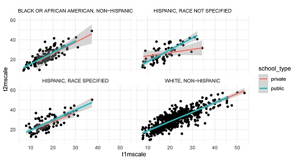

*Done. See plot below. Note that the code I used is not shown.*

```
## [1] "U:/lisas/Hdrive-LisaS/odrive/R/joe nese class/Projects for Labs/lab 6 project"
```

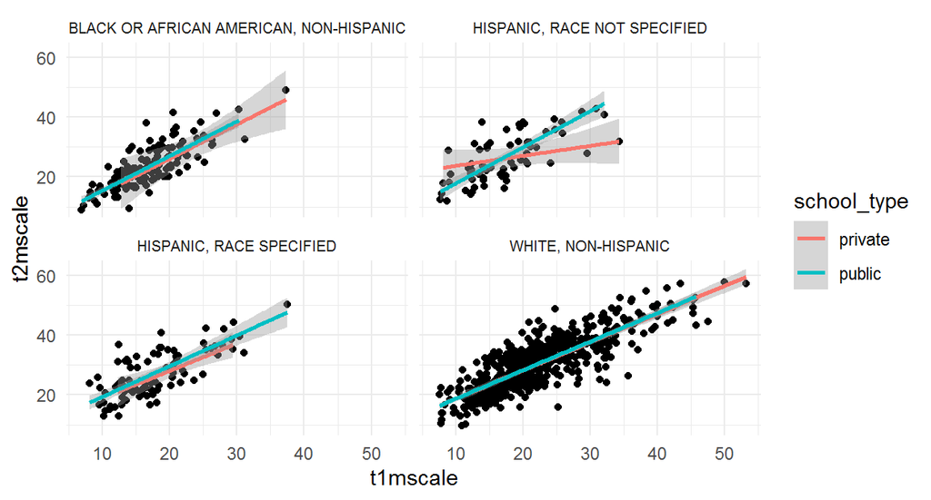

### Question 4.

Run the following lines of code to store the mean and standard deviation of t1mscale.

- t1mean <- mean(eclskclean$t1mscale, na.rm = TRUE)
- t1sd <- sd(eclskclean$t1mscale, na.rm = TRUE)

Extend this code to calculate (in the same code chunk) the mean and standard deviation of t2mscale. Using the values you calculated, use an inline code evaluation below to report the means/SDs for the two time points (t1mscale and t2mscale). Also report the difference between the means (i.e., the average gain).

*Done. See code below.*

```r
t1mean <- round(mean(eclskclean$t1mscale, na.rm = TRUE), digits=2)
t1sd <- round(sd(eclskclean$t1mscale, na.rm = TRUE), digits=2)
t2mean <- round(mean(eclskclean$t2mscale, na.rm = TRUE), digits=2)
t2sd <- round(sd(eclskclean$t2mscale, na.rm = TRUE), digits=2)
```

*Check mean, SD, and difference score values.*

```r
t1mean
```

```
## [1] 20.51
```

```r
t1sd
```

```
## [1] 7.37
```

```r
t2mean
```

```
## [1] 28.57
```

```r
t2sd
```

```
## [1] 8.78
```

```r
t2mean - t1mean
```

```
## [1] 8.06
```

*See sentence below with inline code.*

The mean (SD) was 20.51 (7.37) at time 1 and 28.57 (8.78) at time 2. Average gain was 8.06.

### Question 5.

Pretend you are trying to teach somebody how to load data. Describe the process below that we’ve discussed in class, including why it helps reproducibility, and echo chunks of code as necessary without actually evaluating any of it.

*It helps reproducibility to load data into an R project directory so that data are always accessible, and the R code always works (and analyses can be reproduced), for anyone at any time on any computer.*

*To load data:*

* Create a new R project directory.

* Within this directory create “data” and “scripts” folders.

* Within the scripts folder, create a new R markdown file to contain all the code needed for a certain set of analyses.

* Paste the raw data that you will be importing into the data folder.

* Use the here() function to locate this dataset in the R markdown file.

*For instance, to import the ecls-k_samp.sav SPSS file, Use code like this (for this code, echo = TRUE but eval = FALSE so that you can see the code but it is not actually evaluated):*

```r
eclsk <- import(here("data", "ecls-k_samp.sav"))
```

*Then clean the imported data, using the characterize() code to keep value labels and the clean_names() code to fix variable names (lower case, underscores instead of spaces, etc.). Use the “View” function to see and check the imported dataset.The code looks like this (again, for this code, echo = TRUE but eval = FALSE so that you can see the code but it is not actually evaluated):*

```r
eclskclean <- eclsk %>%
  characterize() %>%
  clean_names()
View(eclskclean)
```

*Does it work? Let’s run the code and view the imported dataset. This time, echo = FALSE and eval = TRUE so that you do not see the code but the code is actually evaluated. Yes!*

```
## [1] "U:/lisas/Hdrive-LisaS/odrive/R/joe nese class/Projects for Labs/lab 6 project"
```

```
##    child_id          teacher_id         school_id
##  Length:984         Length:984         Length:984
##  Class :character   Class :character   Class :character
##  Mode  :character   Mode  :character   Mode  :character
##
##
##
##     k_type          school_type            sex
##  Length:984         Length:984         Length:984
##  Class :character   Class :character   Class :character
##  Mode  :character   Mode  :character   Mode  :character
##
##
##
##     ethnic            famtype             numsibs          ses_cont
##  Length:984         Length:984         Min.   : 0.000   Min.   :-4.4700
##  Class :character   Class :character   1st Qu.: 1.000   1st Qu.:-0.4325
##  Mode  :character   Mode  :character   Median : 1.000   Median :-0.0200
##                                        Mean   : 1.446   Mean   : 0.1048
##                                        3rd Qu.: 2.000   3rd Qu.: 0.6300
##                                        Max.   :10.000   Max.   : 2.5600
##    ses_cat               age           t1rscale        t1mscale
##  Length:984         Min.   :54.00   Min.   :10.67   Min.   : 6.903
##  Class :character   1st Qu.:65.73   1st Qu.:16.95   1st Qu.:15.173
##  Mode  :character   Median :68.98   Median :21.46   Median :19.353
##                     Mean   :68.94   Mean   :23.37   Mean   :20.506
##                     3rd Qu.:72.12   3rd Qu.:27.68   3rd Qu.:24.338
##                     Max.   :79.00   Max.   :66.69   Max.   :53.200
##     t1gscale         t2rscale        t2mscale         t2gscale
##  Min.   : 7.695   Min.   :12.28   Min.   : 8.951   Min.   : 8.59
##  1st Qu.:17.656   1st Qu.:25.19   1st Qu.:21.879   1st Qu.:22.42
##  Median :22.805   Median :32.27   Median :28.363   Median :28.70
##  Mean   :23.228   Mean   :32.95   Mean   :28.567   Mean   :28.32
##  3rd Qu.:28.504   3rd Qu.:38.29   3rd Qu.:34.115   3rd Qu.:33.67
##  Max.   :42.808   Max.   :69.91   Max.   :57.614   Max.   :47.47
##   ir_treadgain      ir_tmathgain      ir_tgkgain         t1arslit
##  Min.   :-10.732   Min.   :-9.469   Min.   :-12.002   Min.   :1.000
##  1st Qu.:  5.122   1st Qu.: 4.473   1st Qu.:  2.510   1st Qu.:2.230
##  Median :  8.808   Median : 7.613   Median :  5.143   Median :2.680
##  Mean   :  9.576   Mean   : 8.061   Mean   :  5.097   Mean   :2.697
```

[output cut: 8 more lines]

```
##  Max.   :5.000   Max.   :5.000   Max.   :5.000   Max.   :5.000
##     t2arsgen      ar_slitgain       ar_smathgain       ar_sgkgain
##  Min.   :1.000   Min.   :-1.7900   Min.   :-1.2300   Min.   :-1.7900
##  1st Qu.:2.980   1st Qu.: 0.3300   1st Qu.: 0.4400   1st Qu.: 0.3275
##  Median :3.950   Median : 0.7100   Median : 0.9550   Median : 0.9700
##  Mean   :3.721   Mean   : 0.7715   Mean   : 0.9653   Mean   : 0.9658
##  3rd Qu.:4.520   3rd Qu.: 1.1525   3rd Qu.: 1.4300   3rd Qu.: 1.5200
##  Max.   :5.000   Max.   : 3.0500   Max.   : 3.6700   Max.   : 4.0000
##    testdate1            testdate2              elapse
##  Min.   :1998-09-12   Min.   :1999-03-11   Min.   :129.0
##  1st Qu.:1998-10-20   1st Qu.:1999-04-22   1st Qu.:170.0
##  Median :1998-11-03   Median :1999-05-04   Median :184.0
##  Mean   :1998-10-31   Mean   :1999-05-04   Mean   :184.7
##  3rd Qu.:1998-11-12   3rd Qu.:1999-05-17   3rd Qu.:199.2
##  Max.   :1998-12-17   Max.   :1999-06-17   Max.   :250.0
```